# Bilan L_Argens

Lilian

2020-07-28

```r
# [[1]] parcequ'on regarde que un bassin, on peut aller un cran plus bas dans "l(indentation des listes)"
data <-  get_simu_appli_grd(parent_dir = dir_appli, project_dir = dir_project, variantes = variantes, bassins = bassin, withdraw_optim = TRUE)[[1]]

date_min <- lapply(data[[1]], function(variant){
  return(variant$ts$Date[1] )
})
date_max<- lapply(data[[1]], function(variant){
  return(variant$ts$Date[length(variant$ts$Date)] )
})

date_min <- do.call(max, date_min)
date_max <- do.call(min, date_max)

data <- lapply(data, function(sub_catch, date_min, date_max){
  sub_catch <- lapply(sub_catch, function(variant, date_min, date_max){
    variant$ts <- subset(variant$ts, Date >= date_min)
    variant$ts <- subset(variant$ts, Date <= date_max)
    return(variant)
  }, date_min = date_min, date_max = date_max)
  return(sub_catch)
}, date_min = date_min, date_max = date_max)

# put on exact same date
# data[[1]] on  rentre dans la liste data$bassin
path_simu <- sapply(data[[1]], function(simu){
  return(file.path(simu$task$path$dir_projet, simu$task$path$subdir))
  })

# make sure that it point a grd onetask and not a crest onetask
onetask <- data[[1]][[1]]$task
if(is.null(onetask$BV$code))onetask$BV$code <- onetask$BV$nom
info_bv <- get_infoBV_grd(simu_dir = file.path(onetask$path$dir_projet, "_BVsets", onetask$BV$nom))

path_fiche <- paste0("https://webgr.inrae.fr/wp-content/uploads/fiches/", info_bv$gauge$Code_BV, "_fiche.png")
```

# 1 Simulations sources

The simulations where located into the fallowing directories :  
* /home/RHAX/UTILISATEURS/lilian.villenave/rendu_stage/data/CREST_VS_GRD/Simu/projet_CREST_vs_GRD/spatial_Validation/ValP2_V3_201208010000_201308010000_201908100000  
* /home/RHAX/UTILISATEURS/lilian.villenave/rendu_stage/data/CREST_VS_GRD/Simu/projet_CREST_vs_GRD/spatial_Validation/ValP2_CALP2_iter5000_201208010000_201308010000_201908010000

The datas have been reduced on the common period : from **2013-08-01**, to **2019-08-01**

You can have acces about the catchment and subcatchments at the fallowing adress :  
https://webgr.inrae.fr/wp-content/uploads/fiches/Y5312010_fiche.png  
https://webgr.inrae.fr/wp-content/uploads/fiches/Y5005210_fiche.png  
https://webgr.inrae.fr/wp-content/uploads/fiches/Y5032010_fiche.png  
https://webgr.inrae.fr/wp-content/uploads/fiches/Y5105010_fiche.png  
https://webgr.inrae.fr/wp-content/uploads/fiches/Y5106610_fiche.png  
https://webgr.inrae.fr/wp-content/uploads/fiches/Y5112010_fiche.png  
https://webgr.inrae.fr/wp-content/uploads/fiches/Y5115020_fiche.png  
https://webgr.inrae.fr/wp-content/uploads/fiches/Y5202010_fiche.png  
https://webgr.inrae.fr/wp-content/uploads/fiches/Y5215020_fiche.png  
https://webgr.inrae.fr/wp-content/uploads/fiches/Y5235010_fiche.png  
https://webgr.inrae.fr/wp-content/uploads/fiches/Y5305015_fiche.png

# 2 Info BV

```r
knitr::kable(info_bv$GRD_domain, format="html", caption = "info of Catchment", row.names = FALSE) %>%
  kable_styling(bootstrap_options = "striped", full_width = F, position = "center")
```

info of Catchment

| param | value |
| --- | --- |
| nbX | 91 |
| nbY | 58 |
| xll | 916000 |
| yll | 6241000 |
| cell_size | 1000 |

```r
knitr::kable(info_bv$gauge, format="html", caption = "info of subcatchments") %>%
  kable_styling(bootstrap_options = "striped", full_width = F, position = "center")
```

info of subcatchments

| Code_BV | Surf | ind_EX | CELLX | CELLY | R_ind_EX | coord_x | coord_y |
| --- | --- | --- | --- | --- | --- | --- | --- |
| Y5312010 | 2512.0450 | 2536 | 79 | 31 | 2809 | 994500 | 6268500 |
| Y5005210 | 143.5975 | 2662 | 23 | 29 | 2571 | 938500 | 6270500 |
| Y5032010 | 506.7750 | 2759 | 29 | 28 | 2486 | 944500 | 6271500 |
| Y5105010 | 202.3400 | 2225 | 41 | 34 | 3044 | 956500 | 6265500 |
| Y5106610 | 235.2975 | 2229 | 45 | 34 | 3048 | 960500 | 6265500 |
| Y5112010 | 1143.6325 | 2683 | 44 | 29 | 2592 | 959500 | 6270500 |
| Y5115020 | 167.5200 | 3413 | 46 | 21 | 1866 | 961500 | 6278500 |
| Y5202010 | 1655.7125 | 2341 | 66 | 33 | 2978 | 981500 | 6266500 |
| Y5215020 | 227.8175 | 1884 | 64 | 38 | 3431 | 979500 | 6261500 |
| Y5235010 | 195.2425 | 2888 | 67 | 27 | 2433 | 982500 | 6272500 |
| Y5305015 | 187.1275 | 2896 | 75 | 27 | 2441 | 990500 | 6272500 |

# 3 Maps

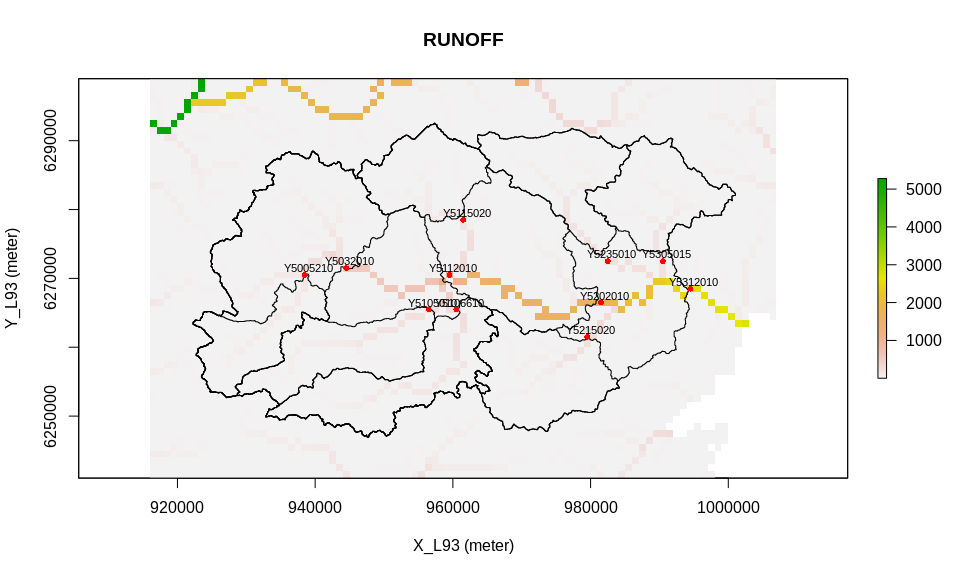

```r
    r <- try(raster(file.path(onetask$path$dir_dataset, bassin, "PARAMS", "RUNOFF.asc")))

    contour <- try(prepare_contour(grep(value = TRUE,
                                    pattern = "contour.txt",
                                    list.files(file.path(onetask$path$dir_projet, "_BVsets", onetask$BV$nom, "PARAMS"), full.names = TRUE))))



    if(class(r) == "try-error")  r <- NA
    if(class(contour) == "try-error") r <- NA


    # traitement du cas particulier runoff : on veut supprimer les valeurs trop hautes pour y voir quelque chose.

      val <- values(r)
      val[val> info_bv$GRD_domain['nbX', 2] * info_bv$GRD_domain['nbY', 2] ] <- info_bv$GRD_domain['nbX', 2] * info_bv$GRD_domain['nbY', 2]

      #   2500 sinon a la place de info_bv$GRD_domain['nbX', 2] * info_bv$GRD_domain['nbY', 2]
      values(r) <- val
      try(
    plot_rast(rast = r,
              contour = contour,
              gauges = info_bv$gauge,
              title = gsub(pattern = "_", replacement = " ", r@data@names)))
```

# 4 Parameters of simulation

```r
for(i in 1:length(data[[1]])){

    cat("##", names(data[[1]])[i], '<br>', '\n')

  if(!grepl("CREST", names(data[[1]])[i])){
    data_with_params <- add_calibration_parameters(data[[1]][[i]], all_param = FALSE)
    cali_params <- data_with_params$parameters
    print(knitr::kable(cali_params, format="html", caption = paste0("parameters for ",names(data[[1]])[i] ), row.names = FALSE) %>%
            kable_styling(bootstrap_options = "striped", full_width = F, position = "center"))

    cat('\n', '<br>', '\n\n')

  }else{
    cali_params <- get_cali_res_crest(data[[1]][[i]])
    print(knitr::kable(cali_params, format="html", caption = paste0("parameters for ",names(data[[1]])[i] ), row.names = FALSE) %>%
            kable_styling(bootstrap_options = "striped", full_width = F, position = "center"))
  }

  write.table(x = cali_params, file =  file.path(export_path, paste0("cali_params_", names(data[[1]])[i],".csv")),
                         append = FALSE,
                         quote = FALSE,
                         sep = ";",
                         col.names = TRUE,
                         row.names = FALSE)
}
```

## 4.1 GRD

parameters for GRD

| ITER | COST | Cp | Ctr | Cr |
| --- | --- | --- | --- | --- |
| 137 | 0.866 | 674.059 | 158.407 | 28.487 |

## 4.2 CREST

parameters for CREST

| gauge | wm | b | im | ke | fc | iwu | under | leaki | th | isu | alpha | beta | alpha0 |
| --- | --- | --- | --- | --- | --- | --- | --- | --- | --- | --- | --- | --- | --- |
| Y5312010 | 246.107376 | 0.433747 | 0.180425 | 0.704696 | 101.949471 | 24.991339 | 0.009884 | 0.018885 | 70.195412 | 0 | 1.689107 | 0.718305 | 0.84505 |

# 5 Availability Data

How to read these data :  
The row indicate the decade and the column indicate the Year of the decade.  
The value indicate the percentage of available data.

```r
 cat('\n', " ##p obs", '\n')
```

```
##
##   ##p obs
```

```r
  dispo(data[[1]][[1]]$ts[,c("Date", "p_obs")])
```

```
##       0    1    2    3    4    5    6    7    8    9
## 2010 X    X    X    100  100  100  100  99.4 99   99.7
##
##
##  mean tot =  99.7256
```

```r
  dispo(data[[1]][[1]]$ts[,c("Date", "p_obs")], save_file = file.path(export_path, "dispo_pobs.txt"))

  cat('\n', "##q obs", '\n')
```

```
##
##  ##q obs
```

```r
for(i in 1:length(data)){
  cat('\n ###', names(data)[i], '\n')

  dispo(data[[i]][[1]]$ts[,c("Date", "q_obs")])

    dispo(data[[i]][[1]]$ts[,c("Date", "q_obs")], save_file = file.path(export_path, paste0("dispo_qobs_", names(data)[i], ".txt")))
}
```

```
##
##  ### Y5312010
##       0    1    2    3    4    5    6    7    8    9
## 2010 X    X    X    90.1 95.6 97.2 96.1 100  98.7 95.9
##
##
##  mean tot =  96.22141
##  ### Y5005210
##       0    1    2    3    4    5    6    7    8    9
## 2010 X    X    X    72.6 44.2 4.19 X    X    X    X
##
##
##  mean tot =  17.28158
##  ### Y5032010
##       0    1    2    3    4    5    6    7    8    9
## 2010 X    X    X    77.1 80.4 91.1 86.7 75.9 94.9 97.5
##
##
##  mean tot =  86.2124
##  ### Y5105010
##       0    1    2    3    4    5    6    7    8    9
## 2010 X    X    X    100  96.3 100  100  90.7 91.4 99.5
##
##
##  mean tot =  96.84274
##  ### Y5106610
##       0    1    2    3    4    5    6    7    8    9
## 2010 X    X    X    84.6 98.3 95.4 63.5 41   79.8 100
##
##
##  mean tot =  80.36086
##  ### Y5112010
##       0    1    2    3    4    5    6    7    8    9
## 2010 X    X    X    96.7 85.2 90.6 85.4 87.4 94.5 71.7
##
##
##  mean tot =  87.35382
##  ### Y5115020
##       0    1    2    3    4    5    6    7    8    9
## 2010 X    X    X    73.5 92.2 96.2 92.3 74.9 96.3 100
```

[output cut: 12 more lines]

```
##
##
##  mean tot =  88.43001
##  ### Y5235010
##       0    1    2    3    4    5    6    7    8    9
## 2010 X    X    X    50.8 96   95.3 93.1 87.1 96.6 99.5
##
##
##  mean tot =  88.34343
##  ### Y5305015
##       0    1    2    3    4    5    6    7    8    9
## 2010 X    X    X    42.5 89.1 100  68.1 43.2 88   71.7
##
##
##  mean tot =  71.80448
```

# 6 global balance

## 6.1 Mean

### 6.1.1 Mean By physical quantity

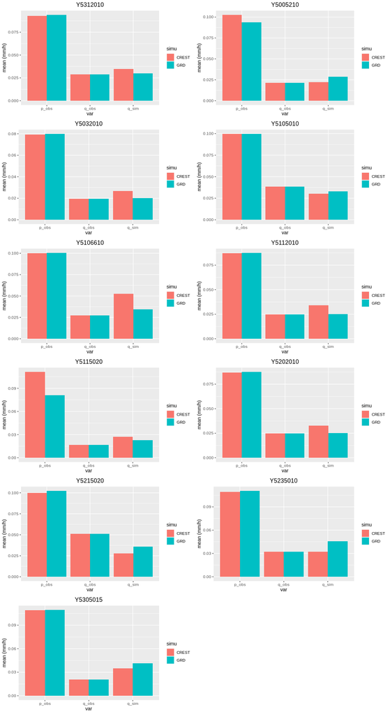

```r
options(default.stringsAsFactors = FALSE)

bilan_brut <- build_bilan(data, "mean", digits = 5)
bilan_brut <- lapply(bilan_brut, function(gauge) {
  names_simu <- names(gauge)
  gauge <- do.call(rbind, gauge)
  gauge <- cbind("simu" = names_simu, gauge)
  return(gauge)})

names_gauge <- character()
k=0
for(i in 1:length(bilan_brut)){
  for(j in 1:nrow(bilan_brut[[i]])){
   k=k+1
   names_gauge[k] <- names(bilan_brut)[i]
  }
}
bilan_brut <- do.call(rbind, bilan_brut)
bilan_brut <- cbind("gauge" = names_gauge, bilan_brut)


p_obs <- q_obs <-q_sim <- bilan_brut

p_obs <- cbind("var" = "p_obs", p_obs[,c("gauge", "simu", "temps_jours", "p_obs")])
q_obs <- cbind("var" = "q_obs", q_obs[,c("gauge", "simu", "temps_jours", "q_obs")])
q_sim <- cbind("var" = "q_sim", q_sim[,c("gauge", "simu", "temps_jours", "q_sim")])
colnames(p_obs) <- colnames(q_obs) <- colnames(q_sim) <- c("var", "gauge", "simu", "temps_jours", "value")

bilan <- rbind(p_obs, q_obs)
bilan <- rbind(bilan, q_sim)
bilan <- as.data.frame(bilan, stringsAsFactors=FALSE)
bilan$value <- as.numeric(bilan$value)


p <- list()
unique_gauge <- as.character(unique(bilan$gauge))
 for(i in 1:length(unique_gauge)){
  new_bilan <- subset(bilan, bilan$gauge == unique_gauge[i])
 p[[i]] <-  ggplot(data=new_bilan, aes(x=var, y=value, fill=simu)) +
  geom_bar(stat="identity", position=position_dodge()) +
  labs(title= paste0(unique_gauge[i]),
                      y="mean (mm/h)")+
  theme(plot.title = element_text(hjust = 0.5))
 }
do.call("grid.arrange", c(p, ncol=2))
```

### 6.1.2 Mean By Outlet

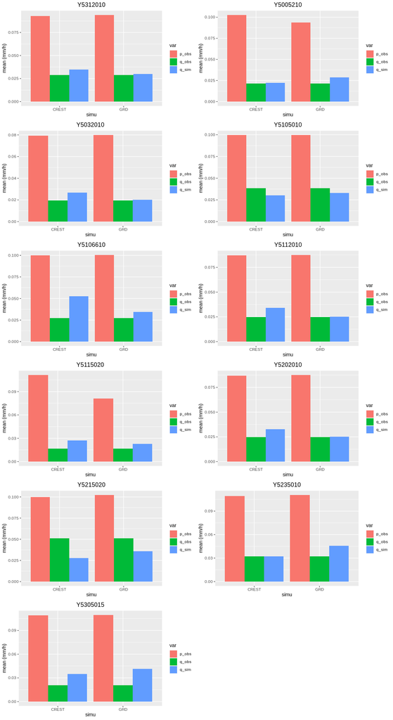

```r
# bilan is the same as in previous chunk
p <- list()
unique_gauge <- as.character(unique(bilan$gauge))
 for(i in 1:length(unique_gauge)){
  new_bilan <- subset(bilan, bilan$gauge == unique_gauge[i])

 p[[i]] <-  ggplot(data=new_bilan, aes(x=simu, y=value, fill=var)) +
  geom_bar(stat="identity", position=position_dodge()) +
  labs(title= paste0(unique_gauge[i]),
                      y="mean (mm/h)")+
  theme(plot.title = element_text(hjust = 0.5))
 }
do.call("grid.arrange", c(p, ncol=2))
```

### 6.1.3 Results as data.frame

```r
# bilan is the same as in previous chunk

knitr::kable(bilan_brut, format="html", caption = "info of subcatchments", row.names = FALSE) %>%
  kable_styling(bootstrap_options = "striped", full_width = F, position = "center")
```

info of subcatchments

| gauge | simu | temps_jours | p_obs | q_obs | q_sim | PET | SM | Fast_Flow | Slow_Flow | nash |
| --- | --- | --- | --- | --- | --- | --- | --- | --- | --- | --- |
| Y5312010 | GRD | 2191 | 0.0939 | 0.02877 | 0.03004 | NA | NA | NA | NA | 0.86569 |
| Y5312010 | CREST | 2191 | 0.093 | 0.02878 | 0.03465 | 0.09176 | 74.06406 | 4e-05 | 0.01385 | 0.72386 |
| Y5005210 | GRD | 2191 | 0.09384 | 0.02132 | 0.02871 | NA | NA | NA | NA | -1.30319 |
| Y5005210 | CREST | 2191 | 0.10256 | 0.02132 | 0.02213 | 0.09173 | 76.09957 | 5e-05 | 0.01592 | -0.17044 |
| Y5032010 | GRD | 2191 | 0.07986 | 0.01937 | 0.02015 | NA | NA | NA | NA | 0.78021 |
| Y5032010 | CREST | 2191 | 0.07915 | 0.01937 | 0.02684 | 0.08916 | 73.23103 | 4e-05 | 0.01032 | 0.46279 |
| Y5105010 | GRD | 2191 | 0.09967 | 0.03831 | 0.03303 | NA | NA | NA | NA | 0.8364 |
| Y5105010 | CREST | 2191 | 0.09956 | 0.03832 | 0.03032 | 0.09233 | 75.60889 | 5e-05 | 0.01515 | 0.55605 |
| Y5106610 | GRD | 2191 | 0.10039 | 0.02732 | 0.03447 | NA | NA | NA | NA | 0.60648 |
| Y5106610 | CREST | 2191 | 0.10024 | 0.02733 | 0.05279 | 0.09275 | 75.08535 | 5e-05 | 0.01556 | 0.28513 |
| Y5112010 | GRD | 2191 | 0.08745 | 0.02478 | 0.02515 | NA | NA | NA | NA | 0.8304 |
| Y5112010 | CREST | 2191 | 0.08724 | 0.02479 | 0.03406 | 0.09127 | 73.81392 | 4e-05 | 0.01225 | 0.55944 |
| Y5115020 | GRD | 2191 | 0.08098 | 0.01651 | 0.02276 | NA | NA | NA | NA | 0.24672 |
| Y5115020 | CREST | 2191 | 0.11124 | 0.01651 | 0.02724 | 0.08231 | 80.09269 | 5e-05 | 0.01919 | -0.15341 |
| Y5202010 | GRD | 2191 | 0.0875 | 0.02479 | 0.02526 | NA | NA | NA | NA | 0.78364 |
| Y5202010 | CREST | 2191 | 0.08687 | 0.02479 | 0.03291 | 0.09129 | 73.67734 | 4e-05 | 0.0122 | 0.49474 |
| Y5215020 | GRD | 2191 | 0.10222 | 0.05095 | 0.03582 | NA | NA | NA | NA | 0.48817 |
| Y5215020 | CREST | 2191 | 0.09993 | 0.05096 | 0.02798 | 0.0954 | 72.46679 | 5e-05 | 0.01566 | 0.19309 |
| Y5235010 | GRD | 2191 | 0.11057 | 0.03212 | 0.04579 | NA | NA | NA | NA | -0.22833 |
| Y5235010 | CREST | 2191 | 0.10942 | 0.03213 | 0.03206 | 0.08371 | 79.18225 | 5e-05 | 0.01865 | 0.72947 |
| Y5305015 | GRD | 2191 | 0.10949 | 0.02064 | 0.04135 | NA | NA | NA | NA | 0.16493 |
| Y5305015 | CREST | 2191 | 0.10904 | 0.02065 | 0.03506 | 0.09151 | 76.37222 | 5e-05 | 0.01802 | 0.61877 |

```r
write.table(x = bilan_brut, file =  file.path(export_path, "global_balance_mean.csv"),
                         append = FALSE,
                         quote = FALSE,
                         sep = ";",
                         col.names = TRUE,
                         row.names = FALSE)
```

## 6.2 Sum

### 6.2.1 Sum By physical quantity

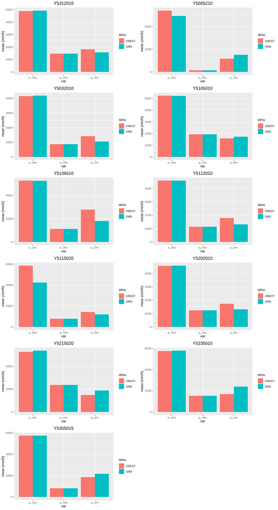

```r
bilan_brut <- build_bilan(data, "sum", digits = 5)

bilan_brut <- lapply(bilan_brut, function(gauge) {
  names_simu <- names(gauge)
  gauge <- do.call(rbind, gauge)
  gauge <- cbind("simu" = names_simu, gauge)
  return(gauge)})

names_gauge <- character()
k=0
for(i in 1:length(bilan_brut)){
  for(j in 1:nrow(bilan_brut[[i]])){
   k=k+1
   names_gauge[k] <- names(bilan_brut)[i]
  }
}
bilan_brut <- do.call(rbind, bilan_brut)
bilan_brut <- cbind("gauge" = names_gauge, bilan_brut)


p_obs <- q_obs <-q_sim <- bilan_brut

p_obs <- cbind("var" = "p_obs", p_obs[,c("gauge", "simu", "temps_jours", "p_obs")])
q_obs <- cbind("var" = "q_obs", q_obs[,c("gauge", "simu", "temps_jours", "q_obs")])
q_sim <- cbind("var" = "q_sim", q_sim[,c("gauge", "simu", "temps_jours", "q_sim")])
colnames(p_obs) <- colnames(q_obs) <- colnames(q_sim) <- c("var", "gauge", "simu", "temps_jours", "value")

bilan <- rbind(p_obs, q_obs)
bilan <- rbind(bilan, q_sim)
bilan <- as.data.frame(bilan, stringsAsFactors=FALSE)
bilan$value <- as.numeric(bilan$value)


p <- list()
 for(i in 1:length(unique(bilan$gauge))){
  new_bilan <- bilan[which(bilan$gauge == unique(bilan$gauge)[i]),]
 p[[i]] <-  ggplot(data=new_bilan, aes(x=var, y=value, fill=simu)) +
  geom_bar(stat="identity", position=position_dodge()) +
  labs(title= paste0(unique(bilan$gauge)[i]),
                      y="mean (mm/h)")+
  theme(plot.title = element_text(hjust = 0.5))
 }
do.call("grid.arrange", c(p, ncol=2))
```

### 6.2.2 Sum By Outlet

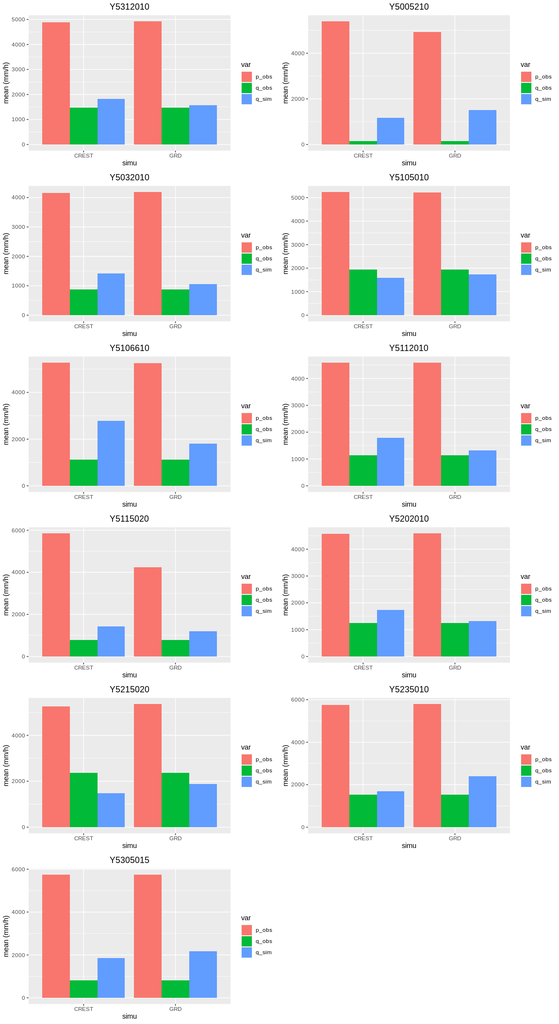

```r
# Bilan defined in the previous chunk

p <- list()
 for(i in 1:length(unique(bilan$gauge))){
  new_bilan <- bilan[which(bilan$gauge == unique(bilan$gauge)[i]),]
 p[[i]] <-  ggplot(data=new_bilan, aes(x=simu, y=value, fill=var)) +
  geom_bar(stat="identity", position=position_dodge()) +
  labs(title= paste0(unique(bilan$gauge)[i]),
                      y="mean (mm/h)")+
  theme(plot.title = element_text(hjust = 0.5))
 }
do.call("grid.arrange", c(p, ncol=2))
```

### 6.2.3 Results as data.frame

```r
# bilan is the same as in previous chunk

knitr::kable(bilan_brut, format="html", caption = "info of subcatchments", row.names = FALSE) %>%
  kable_styling(bootstrap_options = "striped", full_width = F, position = "center")
```

info of subcatchments

| gauge | simu | temps_jours | p_obs | q_obs | q_sim | PET | SM | Fast_Flow | Slow_Flow | nash |
| --- | --- | --- | --- | --- | --- | --- | --- | --- | --- | --- |
| Y5312010 | GRD | 2191 | 4922.9799 | 1465.36558 | 1579.56519 | NA | NA | NA | NA | 0.86569 |
| Y5312010 | CREST | 2191 | 4890.33 | 1465.14571 | 1822.25055 | 4825.16 | 3894658.55 | 2.3434 | 728.2928 | 0.72386 |
| Y5005210 | GRD | 2191 | 4920.10151 | 147.20323 | 1509.65539 | NA | NA | NA | NA | -1.30319 |
| Y5005210 | CREST | 2191 | 5392.92 | 146.97456 | 1163.45326 | 4823.72 | 4001695.63 | 2.6124 | 837.3146 | -0.17044 |
| Y5032010 | GRD | 2191 | 4186.84144 | 879.13293 | 1059.77408 | NA | NA | NA | NA | 0.78021 |
| Y5032010 | CREST | 2191 | 4162.11 | 878.80378 | 1411.58176 | 4688.36 | 3850853.57 | 1.9993 | 542.6293 | 0.46279 |
| Y5105010 | GRD | 2191 | 5225.70056 | 1941.25523 | 1736.81211 | NA | NA | NA | NA | 0.8364 |
| Y5105010 | CREST | 2191 | 5235.29 | 1940.9519 | 1594.56835 | 4855.4 | 3975893.68 | 2.5331 | 796.4505 | 0.55605 |
| Y5106610 | GRD | 2191 | 5263.19457 | 1128.68806 | 1812.60116 | NA | NA | NA | NA | 0.60648 |
| Y5106610 | CREST | 2191 | 5270.98 | 1128.51943 | 2775.93396 | 4877 | 3948363.12 | 2.5514 | 818.2231 | 0.28513 |
| Y5112010 | GRD | 2191 | 4584.8285 | 1140.77183 | 1322.62204 | NA | NA | NA | NA | 0.8304 |
| Y5112010 | CREST | 2191 | 4587.34 | 1140.61883 | 1791.04234 | 4799.24 | 3881504.98 | 2.2055 | 644.0065 | 0.55944 |
| Y5115020 | GRD | 2191 | 4245.82342 | 782.92073 | 1196.96854 | NA | NA | NA | NA | 0.24672 |
| Y5115020 | CREST | 2191 | 5849.46 | 782.59298 | 1432.61347 | 4328.34 | 4211674.14 | 2.8365 | 1009.2035 | -0.15341 |
| Y5202010 | GRD | 2191 | 4587.61734 | 1243.86025 | 1328.30673 | NA | NA | NA | NA | 0.78364 |
| Y5202010 | CREST | 2191 | 4567.87 | 1243.74275 | 1730.38272 | 4800.68 | 3874323.12 | 2.1904 | 641.6993 | 0.49474 |
| Y5215020 | GRD | 2191 | 5359.43416 | 2368.59651 | 1883.38178 | NA | NA | NA | NA | 0.48817 |
| Y5215020 | CREST | 2191 | 5255.08 | 2368.43473 | 1471.56995 | 5016.68 | 3810666.06 | 2.5501 | 823.4531 | 0.19309 |
| Y5235010 | GRD | 2191 | 5797.21555 | 1540.25566 | 2407.60505 | NA | NA | NA | NA | -0.22833 |
| Y5235010 | CREST | 2191 | 5753.65 | 1539.99589 | 1685.85893 | 4401.78 | 4163798.87 | 2.7928 | 980.7804 | 0.72947 |
| Y5305015 | GRD | 2191 | 5740.4191 | 810.24569 | 2174.64705 | NA | NA | NA | NA | 0.16493 |
| Y5305015 | CREST | 2191 | 5734.13 | 810.16915 | 1843.8289 | 4812.2 | 4016033.34 | 2.7752 | 947.7058 | 0.61877 |

```r
 write.table(x = bilan_brut, file =  file.path(export_path, "global_balance_sum.csv"),
                         append = FALSE,
                         quote = FALSE,
                         sep = ";",
                         col.names = TRUE,
                         row.names = FALSE)
```

```r
cat("# Nash {.tabset}")
nash_brut <- bilan_brut[,c("gauge", "simu", "nash", "temps_jours")]
nash_brut <- as.data.frame(nash_brut, stringsAsFactors = FALSE)
for(i in 1:length(unique(nash_brut$gauge))){
    cat("##", unique(nash_brut$gauge)[i], '<br>', '\n')

print(knitr::kable(subset(nash_brut, gauge == unique(nash_brut$gauge)[i]), format="html", caption = "nash & global balance", row.names = FALSE) %>%
  kable_styling(bootstrap_options = "striped", full_width = F, position = "center"))

  cat('\n', '<br>', '\n\n')

}

  write.table(x = nash_brut, file =  file.path(export_path, "nash.csv"),
                         append = FALSE,
                         quote = FALSE,
                         sep = ";",
                         col.names = TRUE,
                         row.names = FALSE)
```

```r
cat("# Perfs {.tabset}")
```

# 7 Perfs

```r
names_gauge <- names(data)

for(i in 1:length(names_gauge)){
    cat("##", names_gauge[i], '<br>', '\n')

  perf <- list()
  for(j in 1:length(data[[names_gauge[i]]])){
    GRD_df <- data[[names_gauge[i]]][[j]]$ts
    if(length(which(!is.na(GRD_df[,"q_obs"])) != 0 )){
      perf[[j]] <- t(hydroGOF::gof(obs = GRD_df[,"q_obs"], sim = GRD_df[,"q_sim"], na.rm = TRUE))
    }else{
      perf[[j]] <- c("ME" = NA,  "MAE"= NA, "MSE"= NA, "RMSE"= NA, "NRMSE"= NA, "% PBIAS %"= NA,  "RSR"= NA,  "rSD"= NA, "NSE"= NA, "mNSE"= NA, "rNSE"= NA,    "d"= NA,   "md"= NA,   "rd"= NA,     "cp"= NA,    "r"= NA,   "R2"= NA, "bR2"= NA,  "KGE"= NA,   "VE"= NA)
    }
  }

perf <- do.call(rbind, perf)
perf <- cbind("variant" = names(data[[names_gauge[i]]]), perf)
perf <- as.data.frame(perf)

print(knitr::kable(perf, format="html", caption = paste0("perforance for", names_gauge[i]), row.names = FALSE) %>%
  kable_styling(bootstrap_options = "striped", full_width = F, position = "center"))

  cat('\n', '<br>', '\n\n')

   write.table(x = perf, file =  file.path(export_path, paste0("hydroGOF_perf_", names_gauge[i],".csv")),
                         append = FALSE,
                         quote = FALSE,
                         sep = ";",
                         col.names = TRUE,
                         row.names = FALSE)
}
```

## 7.1 Y5312010

perforance forY5312010

| variant | ME | MAE | MSE | RMSE | NRMSE % | PBIAS % | RSR | rSD | NSE | mNSE | rNSE | d | md | rd | cp | r | R2 | bR2 | KGE | VE |
| --- | --- | --- | --- | --- | --- | --- | --- | --- | --- | --- | --- | --- | --- | --- | --- | --- | --- | --- | --- | --- |
| GRD | 0 | 0.01 | 0 | 0.02 | 36.6 | 6 | 0.37 | 0.96 | 0.87 | 0.62 | 0.9 | 0.96 | 0.81 | 0.97 | -33.53 | 0.93 | 0.87 | 0.8 | 0.9 | 0.63 |
| CREST | 0.01 | 0.02 | 0 | 0.03 | 52.5 | 22.1 | 0.53 | 0.68 | 0.72 | 0.34 | -0.07 | 0.9 | 0.59 | 0.6 | -70 | 0.88 | 0.78 | 0.55 | 0.59 | 0.37 |

## 7.2 Y5005210

perforance forY5005210

| variant | ME | MAE | MSE | RMSE | NRMSE % | PBIAS % | RSR | rSD | NSE | mNSE | rNSE | d | md | rd | cp | r | R2 | bR2 | KGE | VE |
| --- | --- | --- | --- | --- | --- | --- | --- | --- | --- | --- | --- | --- | --- | --- | --- | --- | --- | --- | --- | --- |
| GRD | 0.02 | 0.02 | 0 | 0.04 | 151.8 | 106.3 | 1.52 | 1.84 | -1.3 | -0.47 | -2.45 | 0.72 | 0.49 | 0.58 | -270.35 | 0.76 | 0.58 | 0.35 | -0.37 | -0.12 |
| CREST | 0.01 | 0.02 | 0 | 0.03 | 108.2 | 36.3 | 1.08 | 1.22 | -0.17 | 0.04 | -1.35 | 0.72 | 0.54 | 0.44 | -137.15 | 0.57 | 0.33 | 0.32 | 0.4 | 0.27 |

## 7.3 Y5032010

perforance forY5032010

| variant | ME | MAE | MSE | RMSE | NRMSE % | PBIAS % | RSR | rSD | NSE | mNSE | rNSE | d | md | rd | cp | r | R2 | bR2 | KGE | VE |
| --- | --- | --- | --- | --- | --- | --- | --- | --- | --- | --- | --- | --- | --- | --- | --- | --- | --- | --- | --- | --- |
| GRD | 0 | 0.01 | 0 | 0.01 | 46.9 | 10.5 | 0.47 | 0.94 | 0.78 | 0.48 | 0.78 | 0.94 | 0.75 | 0.94 | -50.09 | 0.89 | 0.79 | 0.71 | 0.83 | 0.59 |
| CREST | 0.01 | 0.01 | 0 | 0.02 | 73.3 | 46.2 | 0.73 | 0.89 | 0.46 | 0.03 | -0.24 | 0.84 | 0.47 | 0.63 | -123.84 | 0.75 | 0.56 | 0.5 | 0.46 | 0.23 |

## 7.4 Y5105010

perforance forY5105010

| variant | ME | MAE | MSE | RMSE | NRMSE % | PBIAS % | RSR | rSD | NSE | mNSE | rNSE | d | md | rd | cp | r | R2 | bR2 | KGE | VE |
| --- | --- | --- | --- | --- | --- | --- | --- | --- | --- | --- | --- | --- | --- | --- | --- | --- | --- | --- | --- | --- |
| GRD | 0 | 0.01 | 0 | 0.03 | 40.4 | -12.9 | 0.4 | 0.98 | 0.84 | 0.58 | 0.89 | 0.96 | 0.79 | 0.97 | -32.71 | 0.92 | 0.85 | 0.75 | 0.85 | 0.63 |
| CREST | -0.01 | 0.02 | 0 | 0.04 | 66.6 | -20.1 | 0.67 | 0.54 | 0.56 | 0.41 | 0.75 | 0.8 | 0.64 | 0.89 | -90.44 | 0.8 | 0.64 | 0.34 | 0.46 | 0.48 |

## 7.5 Y5106610

perforance forY5106610

| variant | ME | MAE | MSE | RMSE | NRMSE % | PBIAS % | RSR | rSD | NSE | mNSE | rNSE | d | md | rd | cp | r | R2 | bR2 | KGE | VE |
| --- | --- | --- | --- | --- | --- | --- | --- | --- | --- | --- | --- | --- | --- | --- | --- | --- | --- | --- | --- | --- |
| GRD | 0.01 | 0.02 | 0 | 0.04 | 62.7 | 51.4 | 0.63 | 1.31 | 0.61 | 0.34 | -12.09 | 0.92 | 0.67 | -1.52 | -104.02 | 0.91 | 0.82 | 0.66 | 0.39 | 0.22 |
| CREST | 0.03 | 0.04 | 0 | 0.05 | 84.5 | 113.2 | 0.85 | 1.17 | 0.29 | -0.16 | -Inf | 0.85 | 0.42 | -Inf | -189.71 | 0.8 | 0.65 | 0.58 | -0.16 | -0.36 |

## 7.6 Y5112010

perforance forY5112010

| variant | ME | MAE | MSE | RMSE | NRMSE % | PBIAS % | RSR | rSD | NSE | mNSE | rNSE | d | md | rd | cp | r | R2 | bR2 | KGE | VE |
| --- | --- | --- | --- | --- | --- | --- | --- | --- | --- | --- | --- | --- | --- | --- | --- | --- | --- | --- | --- | --- |
| GRD | 0 | 0.01 | 0 | 0.02 | 41.2 | 5.5 | 0.41 | 1.01 | 0.83 | 0.56 | 0.8 | 0.96 | 0.78 | 0.95 | -50.2 | 0.92 | 0.84 | 0.8 | 0.9 | 0.6 |
| CREST | 0.01 | 0.02 | 0 | 0.03 | 66.4 | 41.1 | 0.66 | 0.9 | 0.56 | 0.15 | -1.22 | 0.87 | 0.51 | 0.34 | -131.98 | 0.79 | 0.63 | 0.55 | 0.53 | 0.23 |

## 7.7 Y5115020

perforance forY5115020

| variant | ME | MAE | MSE | RMSE | NRMSE % | PBIAS % | RSR | rSD | NSE | mNSE | rNSE | d | md | rd | cp | r | R2 | bR2 | KGE | VE |
| --- | --- | --- | --- | --- | --- | --- | --- | --- | --- | --- | --- | --- | --- | --- | --- | --- | --- | --- | --- | --- |
| GRD | 0.01 | 0.01 | 0 | 0.03 | 86.8 | 43.3 | 0.87 | 1.12 | 0.25 | 0.08 | 0.67 | 0.8 | 0.6 | 0.91 | -36.31 | 0.69 | 0.47 | 0.41 | 0.45 | 0.25 |
| CREST | 0.01 | 0.02 | 0 | 0.04 | 107.4 | 71.2 | 1.07 | 0.98 | -0.15 | -0.33 | -1.02 | 0.63 | 0.34 | 0.34 | -56.12 | 0.46 | 0.22 | 0.14 | 0.11 | -0.08 |

## 7.8 Y5202010

perforance forY5202010

| variant | ME | MAE | MSE | RMSE | NRMSE % | PBIAS % | RSR | rSD | NSE | mNSE | rNSE | d | md | rd | cp | r | R2 | bR2 | KGE | VE |
| --- | --- | --- | --- | --- | --- | --- | --- | --- | --- | --- | --- | --- | --- | --- | --- | --- | --- | --- | --- | --- |
| GRD | 0 | 0.01 | 0 | 0.02 | 46.5 | 4.8 | 0.47 | 1.04 | 0.78 | 0.5 | 0.85 | 0.95 | 0.75 | 0.96 | -99.03 | 0.9 | 0.8 | 0.77 | 0.88 | 0.57 |
| CREST | 0.01 | 0.02 | 0 | 0.03 | 71.1 | 34.7 | 0.71 | 0.91 | 0.49 | 0.14 | -0.38 | 0.85 | 0.5 | 0.58 | -232.41 | 0.75 | 0.56 | 0.48 | 0.56 | 0.26 |

## 7.9 Y5215020

perforance forY5215020

| variant | ME | MAE | MSE | RMSE | NRMSE % | PBIAS % | RSR | rSD | NSE | mNSE | rNSE | d | md | rd | cp | r | R2 | bR2 | KGE | VE |
| --- | --- | --- | --- | --- | --- | --- | --- | --- | --- | --- | --- | --- | --- | --- | --- | --- | --- | --- | --- | --- |
| GRD | -0.01 | 0.03 | 0.03 | 0.16 | 71.5 | -22.6 | 0.72 | 0.44 | 0.49 | 0.59 | -Inf | 0.73 | 0.76 | -Inf | -10.19 | 0.78 | 0.61 | 0.22 | 0.35 | 0.43 |
| CREST | -0.02 | 0.05 | 0.04 | 0.21 | 89.8 | -43.4 | 0.9 | 0.13 | 0.19 | 0.36 | -Inf | 0.35 | 0.55 | -Inf | -16.64 | 0.83 | 0.69 | 0.09 | 0.01 | 0.11 |

## 7.10 Y5235010

perforance forY5235010

| variant | ME | MAE | MSE | RMSE | NRMSE % | PBIAS % | RSR | rSD | NSE | mNSE | rNSE | d | md | rd | cp | r | R2 | bR2 | KGE | VE |
| --- | --- | --- | --- | --- | --- | --- | --- | --- | --- | --- | --- | --- | --- | --- | --- | --- | --- | --- | --- | --- |
| GRD | 0.02 | 0.03 | 0 | 0.06 | 110.8 | 52 | 1.11 | 1.79 | -0.23 | -0.03 | 0.43 | 0.83 | 0.6 | 0.92 | -27.09 | 0.86 | 0.73 | 0.48 | 0.04 | 0.19 |
| CREST | 0 | 0.02 | 0 | 0.03 | 52 | 4.7 | 0.52 | 0.81 | 0.73 | 0.35 | 0.06 | 0.91 | 0.64 | 0.7 | -5.18 | 0.86 | 0.73 | 0.57 | 0.75 | 0.49 |

## 7.11 Y5305015

perforance forY5305015

| variant | ME | MAE | MSE | RMSE | NRMSE % | PBIAS % | RSR | rSD | NSE | mNSE | rNSE | d | md | rd | cp | r | R2 | bR2 | KGE | VE |
| --- | --- | --- | --- | --- | --- | --- | --- | --- | --- | --- | --- | --- | --- | --- | --- | --- | --- | --- | --- | --- |
| GRD | 0.03 | 0.03 | 0 | 0.07 | 91.4 | 154.6 | 0.91 | 1.36 | 0.16 | -0.29 | -Inf | 0.84 | 0.47 | -Inf | -16.16 | 0.81 | 0.65 | 0.54 | -0.6 | -0.68 |
| CREST | 0.02 | 0.03 | 0 | 0.05 | 61.7 | 88 | 0.62 | 0.56 | 0.62 | 0.02 | -Inf | 0.84 | 0.43 | -Inf | -6.84 | 0.89 | 0.79 | 0.47 | 0.01 | -0.28 |

## 7.12 infos

If you want to know the meaning of the value of each column, click on the link :

[link to documentation of the function](https://www.rdocumentation.org/packages/hydroGOF/versions/0.4-0/topics/gof) And go to the Value section.

```r
cat("# Plot for Multiple simulations {.tabset}")
```

# 8 Plot for Multiple simulations

```r
for (i in 1:length(data)){
  cat("##", names(data)[i], '<br>', '\n')

 try(multi_hydrogram_grd(data_g = data[[i]],
                           name_gauge = names(data)[i],
                           warmup_line = FALSE))

  cat('\n', '<br>', '\n\n')
}
```

## 8.1 Y5312010

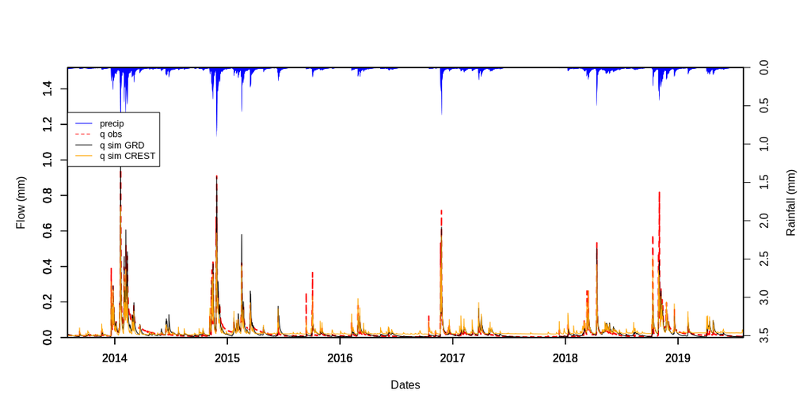

## 8.2 Y5005210

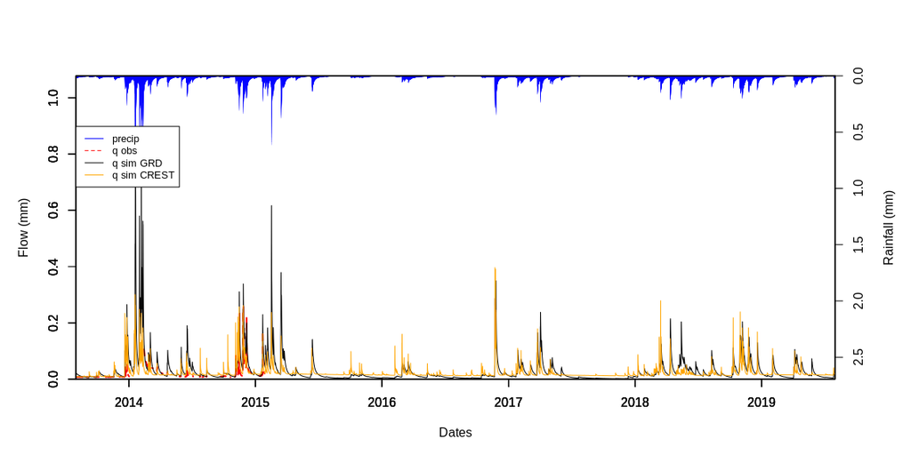

## 8.3 Y5032010

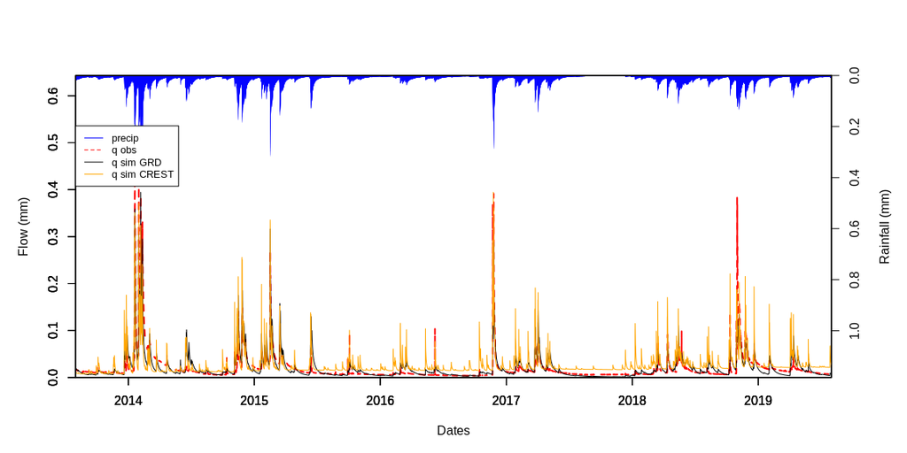

## 8.4 Y5105010

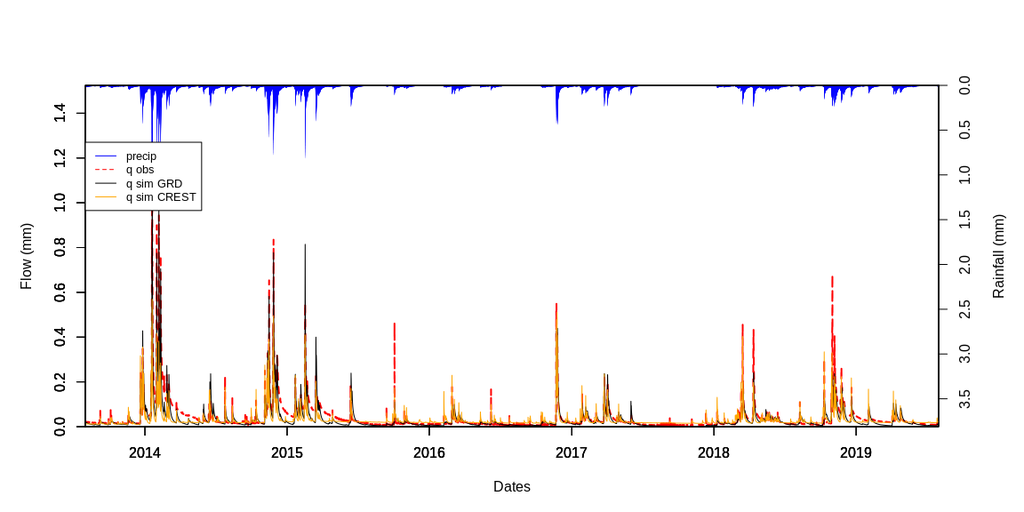

## 8.5 Y5106610

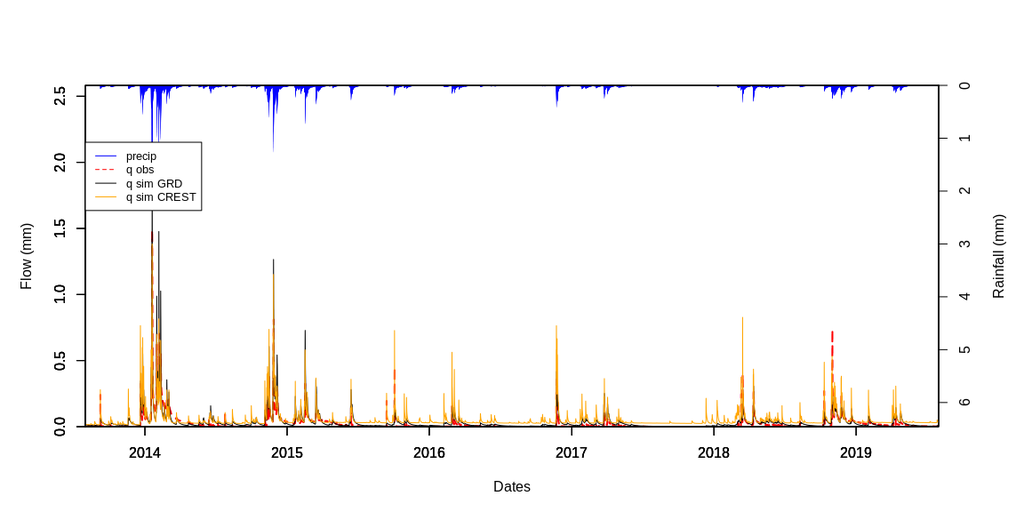

## 8.6 Y5112010

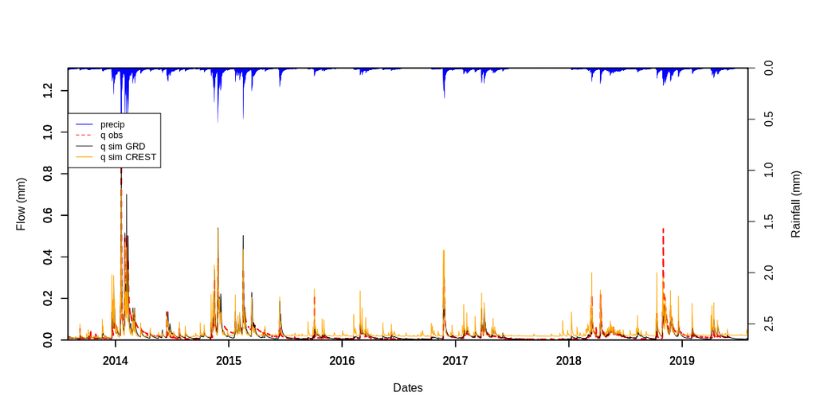

## 8.7 Y5115020

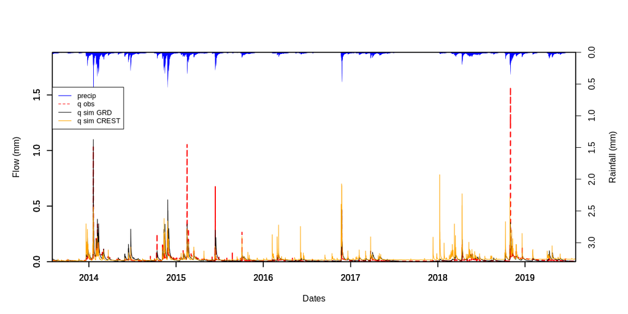

## 8.8 Y5202010

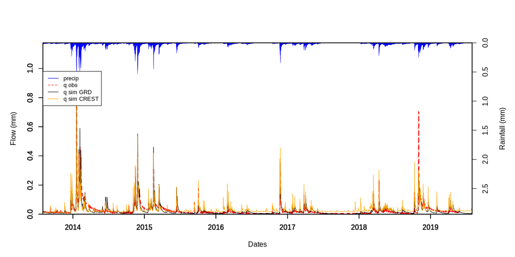

## 8.9 Y5215020

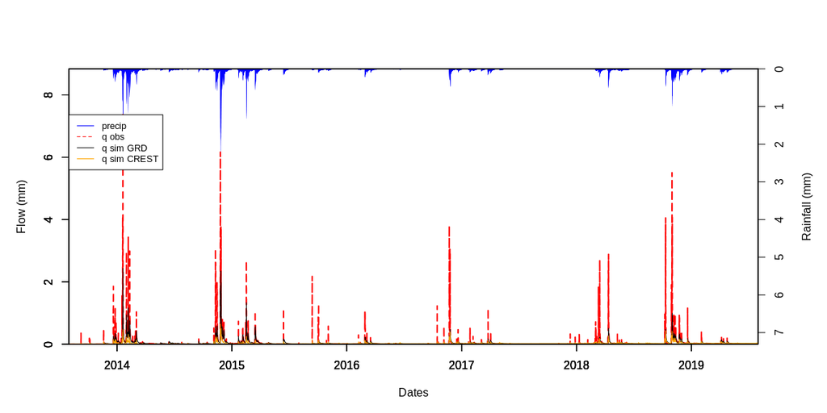

## 8.10 Y5235010

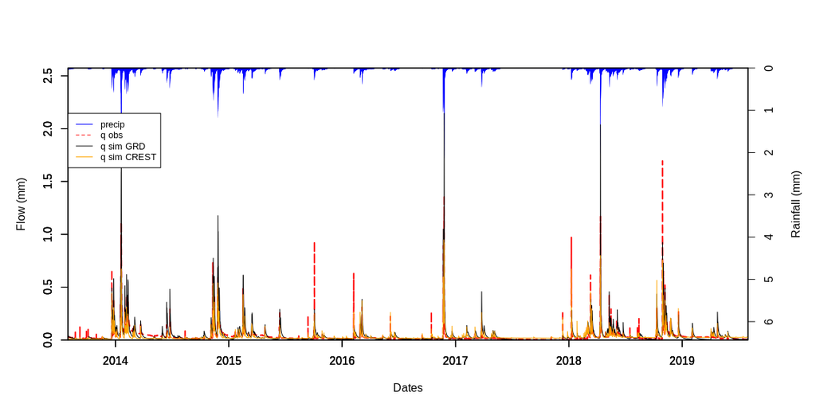

## 8.11 Y5305015

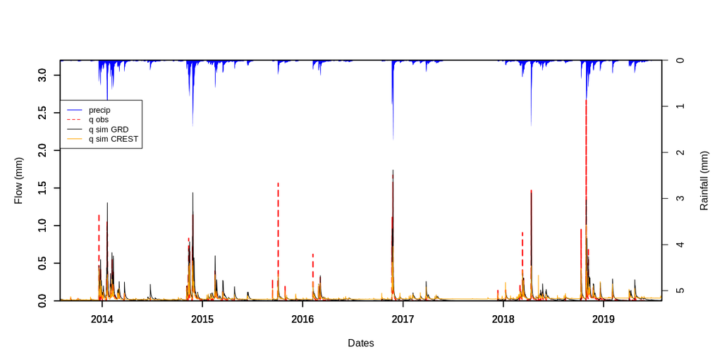

```r
cat("# Plotly for Multiple simulations {.tabset}")
cat("<br> En construction. <br>" )
require(plotly)
for (i in 1:length(data)){
  # cat("##", names(data)[i], '<br>', '\n')

 multi_plotly_hydrogram_grd(data_g = data[[i]],
                           title = paste0("compared hydrogram of ", names(data)[i])
                           )

  # cat('\n', '<br>', '\n\n')
}
```

```r
cat("# Plot of Deviation {.tabset}")
```

# 9 Plot of Deviation

```r
multi_deviation_grd_V2 <- function(data_g, name_gauge, save_dir, date_min,
                                   date_max, plot_size, is.png, warmup_line){


  date_brut <- data_g[[1]]$ts$Date
  if(missing(date_min)) date_min <- date_brut[1]
  if(missing(date_max)) date_max <-date_brut[length(date_brut)]
  if(missing(plot_size)) plot_size <- c("x" = 480, "y" = 380)
  if(missing(is.png)) is.png  <- TRUE
  if(missing(warmup_line)) warmup_line <- FALSE


  # prepare data for plot ----
  data <- lapply(data_g, function(grd_df, date_max){
    grd_df <- grd_df$ts
    return(subset(grd_df, Date <=date_max))}, date_max = date_max)

  data <- lapply(data_g, function(grd_df, date_max){
    grd_df <- grd_df$ts
    return(subset(grd_df, Date >=date_min))}, date_max = date_min)

  # data to plot
  dates <- data[[1]]$Date
  obs_flow <- data[[1]]$q_obs
  rain <- data[[1]]$q_sim

  sim_flow <- lapply(data, function(grd_df){
     vals <- abs((grd_df$q_obs - grd_df$q_sim)/grd_df$q_obs)
     id <- which(is.na(vals))
    vals[id] <- 0
    vals <- cumsum(vals)
    vals[i] <- NA
    return(vals)

    })
  sim_flow <- do.call(cbind, sim_flow)

  # parameters for the plot
  # ylim axis
  max_flow <- max(sim_flow, na.rm = TRUE)
  # name legend
  legende <- c("precip", paste0("q sim ", colnames(sim_flow)))
  # colors for legend and plot
  col_legend <- c("blue", "red", "black", "orange", "purple", "green", "grey")


  # prepare the save the plot ----
  # plot rainfall -----
  ## Plot rainfall first
  par(xaxs="i", yaxs="i", mar=c(5,5,5,5))
  plot(dates, rain, type="h", ylim=c(max(na.omit(rain)),0),
       axes=FALSE, xlab=NA, ylab=NA,
       lwd=0.1, lend="square", col = col_legend[1])
  axis(4)
  mtext("Rainfall (mm)", side=4, line=3)

  # plot q sim ----

    par(new=TRUE)
    plot(dates, sim_flow[,1],  ylim=c(0,1.2*max_flow), type="l", lwd=1, xlab=NA, ylab=NA, col = col_legend[2])

  for(i in 2:ncol(sim_flow)){
    par(new=TRUE)
    lines(dates, sim_flow[,i], type="l", lwd=1,  col = col_legend[1+i])
  }


  # add warmup bar ----
  if(warmup_line){
    abline(v = YYYYMMDDHHMM_to_date(data_g[[1]]$task$date$start_optim), col = "black", lwd = 3, lty = 2) #
    text( x= YYYYMMDDHHMM_to_date(data_g[[1]]$task$date$start_optim) + 20000000, y= max(max_flow), labels = "  Fin Chauffe", col = "black", pos = 3)
  }

  # add legend and title ----
  legend(x = dates[1], y = mean(c(max_flow, mean(sim_flow[,1], na.rm = TRUE))), legend=legende,
         col=col_legend, lty=c(1, 1, 1), cex=0.8)

  graphics::title(main = paste0("Deviation for multiple simuations of ", name_gauge),
                  xlab = "Dates", ylab = "Deviation sum(Qobs(i)-Qsim(i)/Qobs(i)) ")
}



for (i in 1:length(data)){
  cat("##", names(data)[i], '<br>', '\n')

   try(multi_deviation_grd_V2(data_g = data[[i]],
                           name_gauge = names(data)[i],
                           warmup_line = FALSE))

  cat('\n', '<br>', '\n\n')
}
```

## 9.1 Y5312010

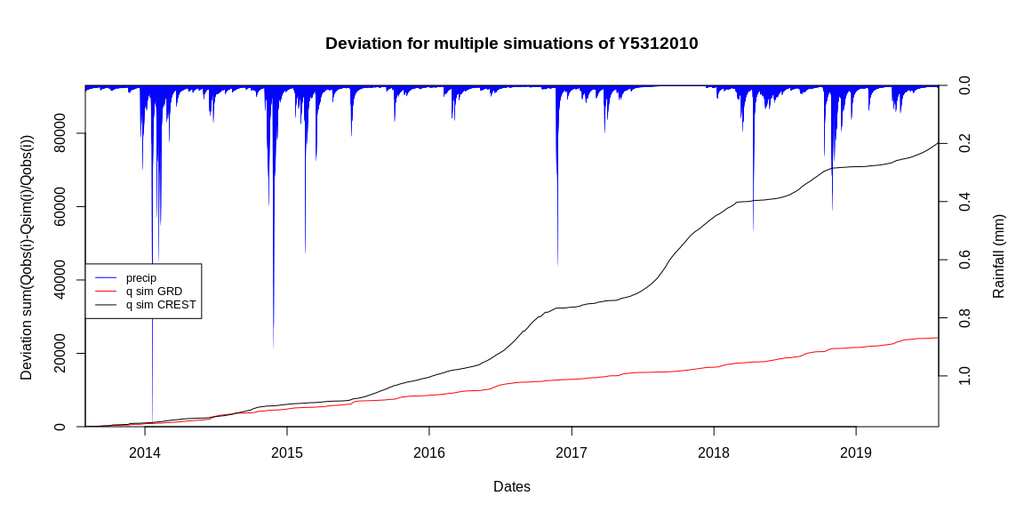

## 9.2 Y5005210

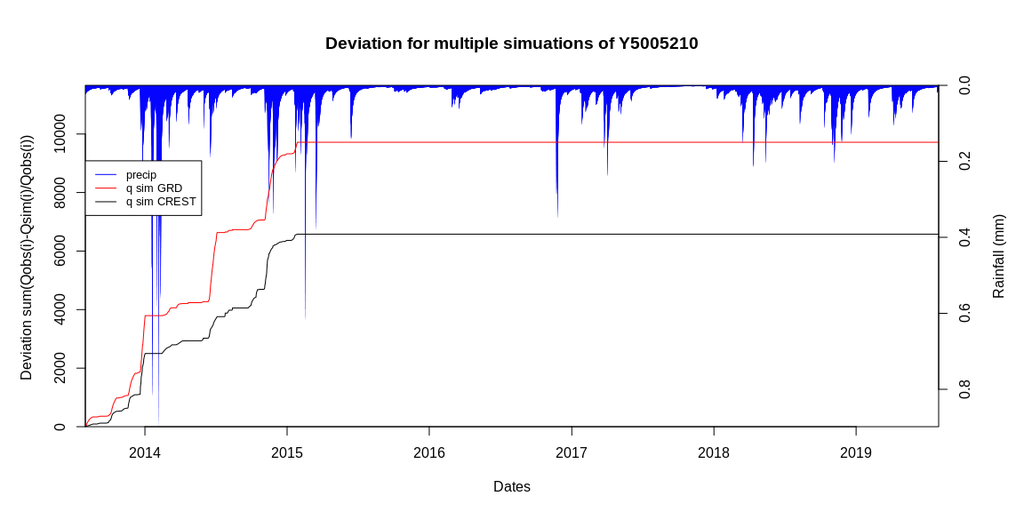

## 9.3 Y5032010

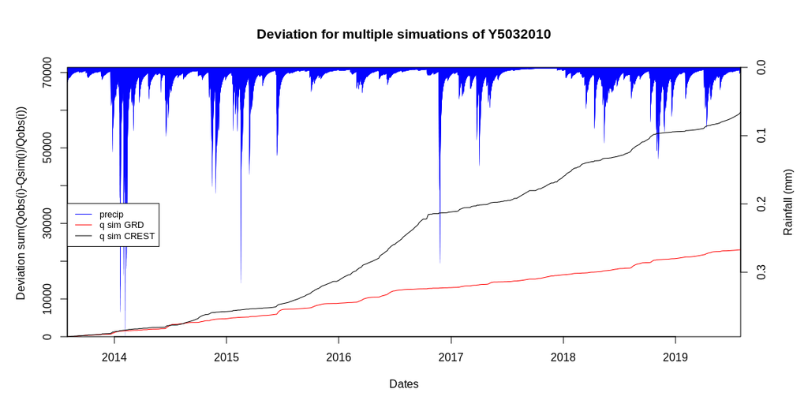

## 9.4 Y5105010

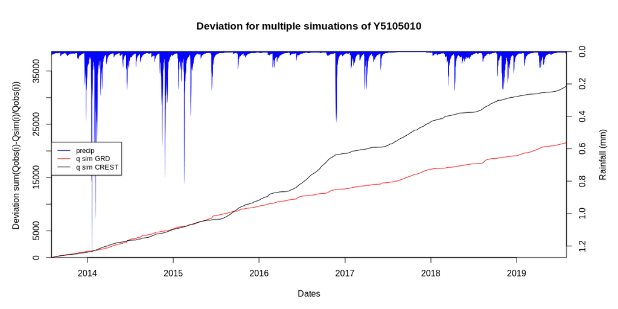

## 9.5 Y5106610

Error in plot.window(...) : valeurs finies requises pour 'ylim'

## 9.6 Y5112010

[figure not shown]

## 9.9 Y5215020

Error in plot.window(...) : valeurs finies requises pour 'ylim'

## 9.11 Y5305015

Error in plot.window(...) : valeurs finies requises pour 'ylim'